# Building Machine Learning Models with Scikit-learn

> We are going to take a look at different machine learning models for solving the problems of regression, clasification and clustering.

## Linear Regression

> Regression algorithms are used when outcome of interest is a continuous variable.

> Linear regression models the relationship between the dependent and independent variables in a linear way.

> The fitted model produces a linear line (or surface for higher dimensional data), which is used to predict the outcome of new data.

> The model tries to minimize the total squared error between the predictions and the actual outcomes. This is often done by using the least squares method.

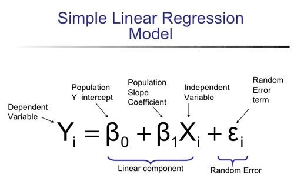

```python
# Importing image into jupyter notebook from code block
from IPython.display import Image
Image(filename='D:/Personal/LEARNING/DATA SCIENCE/PRACTICE/Simple Linear Regression Equation.jpg')
```

> So there is basically two linear regression models that we are going to learn about, one is the simple linear regression and the other one is multiple linear regression. In the simple one we are predicting the outcome variable Y, by using a single input variable X, and we are going to fit a model that will predict the beta0 and beta1 coefficients, beta 0 being the intercept and beta 1 is basically the slope of this line, so that our error epsilon as minimum as possible.

### Mutiple Linear Regression

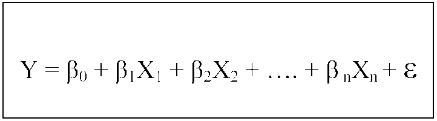

```python
from IPython.display import Image
Image(filename='D:/Personal/LEARNING/DATA SCIENCE/PRACTICE/multiple-linear-regression-equation.png')
```

> Okay it's the same idea with multiple linear regression, only in this case we are able to use more variables, since we have more variables that are disposable more input data, we have more colors or more features, we'll be fitting beta 1, beta 2, up until beta K coefficients, if our data is K dimensional.

```python
import pandas as pd
import numpy as np

import seaborn as sns

import sklearn.datasets as data
```

```python
wine = data.load_wine()
type(wine)
```

```
sklearn.utils.Bunch
```

```python
wine.keys()
```

```
dict_keys(['data', 'target', 'target_names', 'DESCR', 'feature_names'])
```

```python
wine.data
```

```
array([[1.423e+01, 1.710e+00, 2.430e+00, ..., 1.040e+00, 3.920e+00,
        1.065e+03],
       [1.320e+01, 1.780e+00, 2.140e+00, ..., 1.050e+00, 3.400e+00,
        1.050e+03],
       [1.316e+01, 2.360e+00, 2.670e+00, ..., 1.030e+00, 3.170e+00,
        1.185e+03],
       ...,
       [1.327e+01, 4.280e+00, 2.260e+00, ..., 5.900e-01, 1.560e+00,
        8.350e+02],
       [1.317e+01, 2.590e+00, 2.370e+00, ..., 6.000e-01, 1.620e+00,
        8.400e+02],
       [1.413e+01, 4.100e+00, 2.740e+00, ..., 6.100e-01, 1.600e+00,
        5.600e+02]])
```

```python
wine.feature_names
```

```
['alcohol',
 'malic_acid',
 'ash',
 'alcalinity_of_ash',
 'magnesium',
 'total_phenols',
 'flavanoids',
 'nonflavanoid_phenols',
 'proanthocyanins',
 'color_intensity',
 'hue',
 'od280/od315_of_diluted_wines',
 'proline']
```

```python
# Create a dataset using above features
df = pd.DataFrame(wine.data, columns=wine.feature_names)
df
```

|  | alcohol | malic_acid | ash | alcalinity_of_ash | magnesium | total_phenols | flavanoids | nonflavanoid_phenols | proanthocyanins | color_intensity | hue | od280/od315_of_diluted_wines | proline |
| --- | --- | --- | --- | --- | --- | --- | --- | --- | --- | --- | --- | --- | --- |
| 0 | 14.23 | 1.71 | 2.43 | 15.6 | 127.0 | 2.80 | 3.06 | 0.28 | 2.29 | 5.640000 | 1.04 | 3.92 | 1065.0 |
| 1 | 13.20 | 1.78 | 2.14 | 11.2 | 100.0 | 2.65 | 2.76 | 0.26 | 1.28 | 4.380000 | 1.05 | 3.40 | 1050.0 |
| 2 | 13.16 | 2.36 | 2.67 | 18.6 | 101.0 | 2.80 | 3.24 | 0.30 | 2.81 | 5.680000 | 1.03 | 3.17 | 1185.0 |
| 3 | 14.37 | 1.95 | 2.50 | 16.8 | 113.0 | 3.85 | 3.49 | 0.24 | 2.18 | 7.800000 | 0.86 | 3.45 | 1480.0 |
| 4 | 13.24 | 2.59 | 2.87 | 21.0 | 118.0 | 2.80 | 2.69 | 0.39 | 1.82 | 4.320000 | 1.04 | 2.93 | 735.0 |
| 5 | 14.20 | 1.76 | 2.45 | 15.2 | 112.0 | 3.27 | 3.39 | 0.34 | 1.97 | 6.750000 | 1.05 | 2.85 | 1450.0 |
| 6 | 14.39 | 1.87 | 2.45 | 14.6 | 96.0 | 2.50 | 2.52 | 0.30 | 1.98 | 5.250000 | 1.02 | 3.58 | 1290.0 |
| 7 | 14.06 | 2.15 | 2.61 | 17.6 | 121.0 | 2.60 | 2.51 | 0.31 | 1.25 | 5.050000 | 1.06 | 3.58 | 1295.0 |
| 8 | 14.83 | 1.64 | 2.17 | 14.0 | 97.0 | 2.80 | 2.98 | 0.29 | 1.98 | 5.200000 | 1.08 | 2.85 | 1045.0 |
| 9 | 13.86 | 1.35 | 2.27 | 16.0 | 98.0 | 2.98 | 3.15 | 0.22 | 1.85 | 7.220000 | 1.01 | 3.55 | 1045.0 |
| 10 | 14.10 | 2.16 | 2.30 | 18.0 | 105.0 | 2.95 | 3.32 | 0.22 | 2.38 | 5.750000 | 1.25 | 3.17 | 1510.0 |
| 11 | 14.12 | 1.48 | 2.32 | 16.8 | 95.0 | 2.20 | 2.43 | 0.26 | 1.57 | 5.000000 | 1.17 | 2.82 | 1280.0 |
| 12 | 13.75 | 1.73 | 2.41 | 16.0 | 89.0 | 2.60 | 2.76 | 0.29 | 1.81 | 5.600000 | 1.15 | 2.90 | 1320.0 |
| 13 | 14.75 | 1.73 | 2.39 | 11.4 | 91.0 | 3.10 | 3.69 | 0.43 | 2.81 | 5.400000 | 1.25 | 2.73 | 1150.0 |
| 14 | 14.38 | 1.87 | 2.38 | 12.0 | 102.0 | 3.30 | 3.64 | 0.29 | 2.96 | 7.500000 | 1.20 | 3.00 | 1547.0 |
| 15 | 13.63 | 1.81 | 2.70 | 17.2 | 112.0 | 2.85 | 2.91 | 0.30 | 1.46 | 7.300000 | 1.28 | 2.88 | 1310.0 |
| 16 | 14.30 | 1.92 | 2.72 | 20.0 | 120.0 | 2.80 | 3.14 | 0.33 | 1.97 | 6.200000 | 1.07 | 2.65 | 1280.0 |
| 17 | 13.83 | 1.57 | 2.62 | 20.0 | 115.0 | 2.95 | 3.40 | 0.40 | 1.72 | 6.600000 | 1.13 | 2.57 | 1130.0 |
| 18 | 14.19 | 1.59 | 2.48 | 16.5 | 108.0 | 3.30 | 3.93 | 0.32 | 1.86 | 8.700000 | 1.23 | 2.82 | 1680.0 |
| 19 | 13.64 | 3.10 | 2.56 | 15.2 | 116.0 | 2.70 | 3.03 | 0.17 | 1.66 | 5.100000 | 0.96 | 3.36 | 845.0 |
| 20 | 14.06 | 1.63 | 2.28 | 16.0 | 126.0 | 3.00 | 3.17 | 0.24 | 2.10 | 5.650000 | 1.09 | 3.71 | 780.0 |
| 21 | 12.93 | 3.80 | 2.65 | 18.6 | 102.0 | 2.41 | 2.41 | 0.25 | 1.98 | 4.500000 | 1.03 | 3.52 | 770.0 |
| 22 | 13.71 | 1.86 | 2.36 | 16.6 | 101.0 | 2.61 | 2.88 | 0.27 | 1.69 | 3.800000 | 1.11 | 4.00 | 1035.0 |
| 23 | 12.85 | 1.60 | 2.52 | 17.8 | 95.0 | 2.48 | 2.37 | 0.26 | 1.46 | 3.930000 | 1.09 | 3.63 | 1015.0 |
| 24 | 13.50 | 1.81 | 2.61 | 20.0 | 96.0 | 2.53 | 2.61 | 0.28 | 1.66 | 3.520000 | 1.12 | 3.82 | 845.0 |
| 25 | 13.05 | 2.05 | 3.22 | 25.0 | 124.0 | 2.63 | 2.68 | 0.47 | 1.92 | 3.580000 | 1.13 | 3.20 | 830.0 |
| 26 | 13.39 | 1.77 | 2.62 | 16.1 | 93.0 | 2.85 | 2.94 | 0.34 | 1.45 | 4.800000 | 0.92 | 3.22 | 1195.0 |
| 27 | 13.30 | 1.72 | 2.14 | 17.0 | 94.0 | 2.40 | 2.19 | 0.27 | 1.35 | 3.950000 | 1.02 | 2.77 | 1285.0 |
| 28 | 13.87 | 1.90 | 2.80 | 19.4 | 107.0 | 2.95 | 2.97 | 0.37 | 1.76 | 4.500000 | 1.25 | 3.40 | 915.0 |
| 29 | 14.02 | 1.68 | 2.21 | 16.0 | 96.0 | 2.65 | 2.33 | 0.26 | 1.98 | 4.700000 | 1.04 | 3.59 | 1035.0 |
| ... | ... | ... | ... | ... | ... | ... | ... | ... | ... | ... | ... | ... | ... |
| 148 | 13.32 | 3.24 | 2.38 | 21.5 | 92.0 | 1.93 | 0.76 | 0.45 | 1.25 | 8.420000 | 0.55 | 1.62 | 650.0 |
| 149 | 13.08 | 3.90 | 2.36 | 21.5 | 113.0 | 1.41 | 1.39 | 0.34 | 1.14 | 9.400000 | 0.57 | 1.33 | 550.0 |
| 150 | 13.50 | 3.12 | 2.62 | 24.0 | 123.0 | 1.40 | 1.57 | 0.22 | 1.25 | 8.600000 | 0.59 | 1.30 | 500.0 |
| 151 | 12.79 | 2.67 | 2.48 | 22.0 | 112.0 | 1.48 | 1.36 | 0.24 | 1.26 | 10.800000 | 0.48 | 1.47 | 480.0 |
| 152 | 13.11 | 1.90 | 2.75 | 25.5 | 116.0 | 2.20 | 1.28 | 0.26 | 1.56 | 7.100000 | 0.61 | 1.33 | 425.0 |
| 153 | 13.23 | 3.30 | 2.28 | 18.5 | 98.0 | 1.80 | 0.83 | 0.61 | 1.87 | 10.520000 | 0.56 | 1.51 | 675.0 |
| 154 | 12.58 | 1.29 | 2.10 | 20.0 | 103.0 | 1.48 | 0.58 | 0.53 | 1.40 | 7.600000 | 0.58 | 1.55 | 640.0 |
| 155 | 13.17 | 5.19 | 2.32 | 22.0 | 93.0 | 1.74 | 0.63 | 0.61 | 1.55 | 7.900000 | 0.60 | 1.48 | 725.0 |
| 156 | 13.84 | 4.12 | 2.38 | 19.5 | 89.0 | 1.80 | 0.83 | 0.48 | 1.56 | 9.010000 | 0.57 | 1.64 | 480.0 |
| 157 | 12.45 | 3.03 | 2.64 | 27.0 | 97.0 | 1.90 | 0.58 | 0.63 | 1.14 | 7.500000 | 0.67 | 1.73 | 880.0 |
| 158 | 14.34 | 1.68 | 2.70 | 25.0 | 98.0 | 2.80 | 1.31 | 0.53 | 2.70 | 13.000000 | 0.57 | 1.96 | 660.0 |
| 159 | 13.48 | 1.67 | 2.64 | 22.5 | 89.0 | 2.60 | 1.10 | 0.52 | 2.29 | 11.750000 | 0.57 | 1.78 | 620.0 |
| 160 | 12.36 | 3.83 | 2.38 | 21.0 | 88.0 | 2.30 | 0.92 | 0.50 | 1.04 | 7.650000 | 0.56 | 1.58 | 520.0 |
| 161 | 13.69 | 3.26 | 2.54 | 20.0 | 107.0 | 1.83 | 0.56 | 0.50 | 0.80 | 5.880000 | 0.96 | 1.82 | 680.0 |
| 162 | 12.85 | 3.27 | 2.58 | 22.0 | 106.0 | 1.65 | 0.60 | 0.60 | 0.96 | 5.580000 | 0.87 | 2.11 | 570.0 |
| 163 | 12.96 | 3.45 | 2.35 | 18.5 | 106.0 | 1.39 | 0.70 | 0.40 | 0.94 | 5.280000 | 0.68 | 1.75 | 675.0 |
| 164 | 13.78 | 2.76 | 2.30 | 22.0 | 90.0 | 1.35 | 0.68 | 0.41 | 1.03 | 9.580000 | 0.70 | 1.68 | 615.0 |
| 165 | 13.73 | 4.36 | 2.26 | 22.5 | 88.0 | 1.28 | 0.47 | 0.52 | 1.15 | 6.620000 | 0.78 | 1.75 | 520.0 |
| 166 | 13.45 | 3.70 | 2.60 | 23.0 | 111.0 | 1.70 | 0.92 | 0.43 | 1.46 | 10.680000 | 0.85 | 1.56 | 695.0 |
| 167 | 12.82 | 3.37 | 2.30 | 19.5 | 88.0 | 1.48 | 0.66 | 0.40 | 0.97 | 10.260000 | 0.72 | 1.75 | 685.0 |
| 168 | 13.58 | 2.58 | 2.69 | 24.5 | 105.0 | 1.55 | 0.84 | 0.39 | 1.54 | 8.660000 | 0.74 | 1.80 | 750.0 |
| 169 | 13.40 | 4.60 | 2.86 | 25.0 | 112.0 | 1.98 | 0.96 | 0.27 | 1.11 | 8.500000 | 0.67 | 1.92 | 630.0 |
| 170 | 12.20 | 3.03 | 2.32 | 19.0 | 96.0 | 1.25 | 0.49 | 0.40 | 0.73 | 5.500000 | 0.66 | 1.83 | 510.0 |
| 171 | 12.77 | 2.39 | 2.28 | 19.5 | 86.0 | 1.39 | 0.51 | 0.48 | 0.64 | 9.899999 | 0.57 | 1.63 | 470.0 |
| 172 | 14.16 | 2.51 | 2.48 | 20.0 | 91.0 | 1.68 | 0.70 | 0.44 | 1.24 | 9.700000 | 0.62 | 1.71 | 660.0 |
| 173 | 13.71 | 5.65 | 2.45 | 20.5 | 95.0 | 1.68 | 0.61 | 0.52 | 1.06 | 7.700000 | 0.64 | 1.74 | 740.0 |
| 174 | 13.40 | 3.91 | 2.48 | 23.0 | 102.0 | 1.80 | 0.75 | 0.43 | 1.41 | 7.300000 | 0.70 | 1.56 | 750.0 |
| 175 | 13.27 | 4.28 | 2.26 | 20.0 | 120.0 | 1.59 | 0.69 | 0.43 | 1.35 | 10.200000 | 0.59 | 1.56 | 835.0 |
| 176 | 13.17 | 2.59 | 2.37 | 20.0 | 120.0 | 1.65 | 0.68 | 0.53 | 1.46 | 9.300000 | 0.60 | 1.62 | 840.0 |
| 177 | 14.13 | 4.10 | 2.74 | 24.5 | 96.0 | 2.05 | 0.76 | 0.56 | 1.35 | 9.200000 | 0.61 | 1.60 | 560.0 |

178 rows × 13 columns

```python
wine.target
```

```
array([0, 0, 0, 0, 0, 0, 0, 0, 0, 0, 0, 0, 0, 0, 0, 0, 0, 0, 0, 0, 0, 0,
       0, 0, 0, 0, 0, 0, 0, 0, 0, 0, 0, 0, 0, 0, 0, 0, 0, 0, 0, 0, 0, 0,
       0, 0, 0, 0, 0, 0, 0, 0, 0, 0, 0, 0, 0, 0, 0, 1, 1, 1, 1, 1, 1, 1,
       1, 1, 1, 1, 1, 1, 1, 1, 1, 1, 1, 1, 1, 1, 1, 1, 1, 1, 1, 1, 1, 1,
       1, 1, 1, 1, 1, 1, 1, 1, 1, 1, 1, 1, 1, 1, 1, 1, 1, 1, 1, 1, 1, 1,
       1, 1, 1, 1, 1, 1, 1, 1, 1, 1, 1, 1, 1, 1, 1, 1, 1, 1, 1, 1, 2, 2,
       2, 2, 2, 2, 2, 2, 2, 2, 2, 2, 2, 2, 2, 2, 2, 2, 2, 2, 2, 2, 2, 2,
       2, 2, 2, 2, 2, 2, 2, 2, 2, 2, 2, 2, 2, 2, 2, 2, 2, 2, 2, 2, 2, 2,
       2, 2])
```

```python
df['wine_type'] = wine.target
```

```python
df.info()
```

```
<class 'pandas.core.frame.DataFrame'>
RangeIndex: 178 entries, 0 to 177
Data columns (total 14 columns):
alcohol                         178 non-null float64
malic_acid                      178 non-null float64
ash                             178 non-null float64
alcalinity_of_ash               178 non-null float64
magnesium                       178 non-null float64
total_phenols                   178 non-null float64
flavanoids                      178 non-null float64
nonflavanoid_phenols            178 non-null float64
proanthocyanins                 178 non-null float64
color_intensity                 178 non-null float64
hue                             178 non-null float64
od280/od315_of_diluted_wines    178 non-null float64
proline                         178 non-null float64
wine_type                       178 non-null int32
dtypes: float64(13), int32(1)
memory usage: 18.9 KB
```

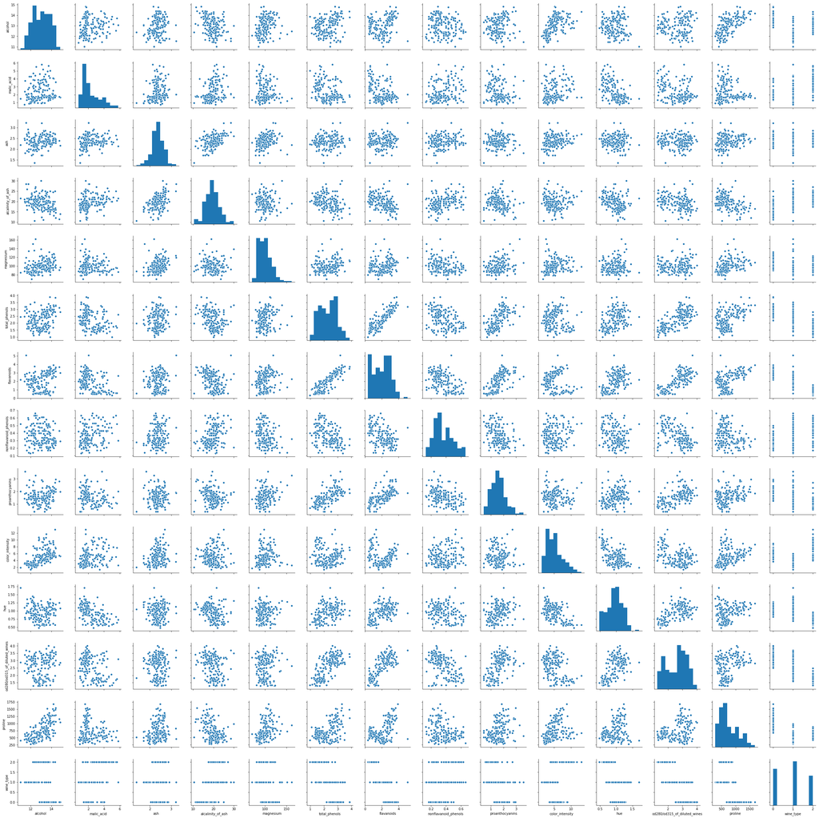

```python
sns.pairplot(df)
```

> Since we are doing linear regression and in regression problems the outcome should be continuous. We will be using alcohol and try to predict the alcohol value by using other features in the data set, okay. When you do the pair plot you can see alcohol as first feature. So for the first example for the simple linear regression case we'll be using only a single feature so if I were to ask you to choose a single feature out of all these features which one would you choose?

> So if I were to choose one I would definitely choose either color intensity the other is pro-line. Now between the two it seems like well they are very similar but I'll just choose proline. Okay let's go with that, so I do hope that we'll get some good model even when use it when we use a single variable like this.

```python
from sklearn.linear_model import LinearRegression
```

```python
reg = LinearRegression()
reg
```

```
LinearRegression(copy_X=True, fit_intercept=True, n_jobs=None,
         normalize=False)
```

```python
# Create input and outcomes x and y respectively
x = df['proline']
y = df['alcohol']
```

```python
# let's fit the model to the data, now I'm expecting an error
reg.fit(x, y)
```

[output not shown]

> From the requirements of sklearn, X should be a 2D array or a Pandas DataFrame or a matrix, okay basically it should have two dimensions tabular data.

> We need to convert X to a DataFrame

```python
x = df[['proline']]
type(x)
```

```
pandas.core.frame.DataFrame
```

```python
reg.fit(x, y)
```

```
LinearRegression(copy_X=True, fit_intercept=True, n_jobs=None,
         normalize=False)
```

```python
pred = reg.predict(x)
```

```python
from sklearn import metrics
```

```python
metrics.r2_score(y, pred)
```

```
0.41437548626472054
```

```python
# Now let's do multi regression
# We are dropping the columns 'alcohol' as it is the target and 'wine_type' as it is categorical.
X = df.drop(['alcohol','wine_type'], axis=1)
X.head()
```

|  | malic_acid | ash | alcalinity_of_ash | magnesium | total_phenols | flavanoids | nonflavanoid_phenols | proanthocyanins | color_intensity | hue | od280/od315_of_diluted_wines | proline |
| --- | --- | --- | --- | --- | --- | --- | --- | --- | --- | --- | --- | --- |
| 0 | 1.71 | 2.43 | 15.6 | 127.0 | 2.80 | 3.06 | 0.28 | 2.29 | 5.64 | 1.04 | 3.92 | 1065.0 |
| 1 | 1.78 | 2.14 | 11.2 | 100.0 | 2.65 | 2.76 | 0.26 | 1.28 | 4.38 | 1.05 | 3.40 | 1050.0 |
| 2 | 2.36 | 2.67 | 18.6 | 101.0 | 2.80 | 3.24 | 0.30 | 2.81 | 5.68 | 1.03 | 3.17 | 1185.0 |
| 3 | 1.95 | 2.50 | 16.8 | 113.0 | 3.85 | 3.49 | 0.24 | 2.18 | 7.80 | 0.86 | 3.45 | 1480.0 |
| 4 | 2.59 | 2.87 | 21.0 | 118.0 | 2.80 | 2.69 | 0.39 | 1.82 | 4.32 | 1.04 | 2.93 | 735.0 |

```python
reg.fit(X, y)
```

```
LinearRegression(copy_X=True, fit_intercept=True, n_jobs=None,
         normalize=False)
```

```python
pred = reg.predict(X)
```

```python
metrics.r2_score(y, pred)
```

```
0.5935573146395274
```

## Logistic Regression

> When output variable is a category of limited number of possibilities then the classification methods.

> In logistic direction the linear model that was used in linear regression case is transformed by using the sigmoid function, so that the predictions always lie in between zero and one.

> Binary dependent variable can be extended so registration is good when your outcome variable is of binary case, but it also can be extended to predict outputs with more than two variables.

> It is a part of a family called generalized linear models

```python
# input and outcome variables
x_in = df.drop('wine_type', axis=1)
#x_in = df[['proline']]
y_out = df['wine_type']
```

```python
from sklearn.linear_model import LogisticRegression
```

```python
clf = LogisticRegression()
clf
```

```
LogisticRegression(C=1.0, class_weight=None, dual=False, fit_intercept=True,
          intercept_scaling=1, max_iter=100, multi_class='warn',
          n_jobs=None, penalty='l2', random_state=None, solver='warn',
          tol=0.0001, verbose=0, warm_start=False)
```

```python
clf.fit(x_in, y_out)
pred = clf.predict(x_in)
```

```python
metrics.accuracy_score(y_out, pred)
```

```
0.9719101123595506
```

## K-Nearest Neighbors

> K-Nearest neighbors is an instance based learning algorithm, which means no explicit training.

> Compares instances being queried with instances from the training set and classifies based on distance.

> Classifies points based on distance to closest K number of points, hence it's called k-nearest neighbors.

> Learning is done by similarity meaning the most similar points which are closest to the point of interest determine its class, based on majority voting.

> It's not good with high dimensional data because as you get more and more dimensional the data you have the data points becomes more and more sparse, and sparse data set is not easy to deal with, especially when you are calculating distances, so this is called the curse of dimensionality.

> Categorical features in our data sets which is again not very friendly with k-nearest neighbors, again the problem is about calculating the distances even if you convert that categorical with one hot encoding to dummy variables still it's not really intuitive what it means you know between the distance between two values of a category.

> Normalizing the data usually will increase accuracy, otherwise variables with larger values will dominate the distance metric. Now imagine if you have one feature which ranges with where its values range from 0 to 1, in another feature which ranges from 0 to thousands or maybe 10,000, now that one with larger range that will dominate definitely and the distance metric, so in order to prevent that normalization methods are used to overcome that problem.

```python
df.head()
```

|  | alcohol | malic_acid | ash | alcalinity_of_ash | magnesium | total_phenols | flavanoids | nonflavanoid_phenols | proanthocyanins | color_intensity | hue | od280/od315_of_diluted_wines | proline | wine_type |
| --- | --- | --- | --- | --- | --- | --- | --- | --- | --- | --- | --- | --- | --- | --- |
| 0 | 14.23 | 1.71 | 2.43 | 15.6 | 127.0 | 2.80 | 3.06 | 0.28 | 2.29 | 5.64 | 1.04 | 3.92 | 1065.0 | 0 |
| 1 | 13.20 | 1.78 | 2.14 | 11.2 | 100.0 | 2.65 | 2.76 | 0.26 | 1.28 | 4.38 | 1.05 | 3.40 | 1050.0 | 0 |
| 2 | 13.16 | 2.36 | 2.67 | 18.6 | 101.0 | 2.80 | 3.24 | 0.30 | 2.81 | 5.68 | 1.03 | 3.17 | 1185.0 | 0 |
| 3 | 14.37 | 1.95 | 2.50 | 16.8 | 113.0 | 3.85 | 3.49 | 0.24 | 2.18 | 7.80 | 0.86 | 3.45 | 1480.0 | 0 |
| 4 | 13.24 | 2.59 | 2.87 | 21.0 | 118.0 | 2.80 | 2.69 | 0.39 | 1.82 | 4.32 | 1.04 | 2.93 | 735.0 | 0 |

```python
from sklearn.neighbors import KNeighborsClassifier
```

```python
clf = KNeighborsClassifier()
clf
```

```
KNeighborsClassifier(algorithm='auto', leaf_size=30, metric='minkowski',
           metric_params=None, n_jobs=None, n_neighbors=5, p=2,
           weights='uniform')
```

```python
# input and output
#x = df[['proline']]
x = df.drop('wine_type',axis=1)
y = df['wine_type']
```

```python
clf.fit(x,y)
```

```
KNeighborsClassifier(algorithm='auto', leaf_size=30, metric='minkowski',
           metric_params=None, n_jobs=None, n_neighbors=5, p=2,
           weights='uniform')
```

```python
pred = clf.predict(x)
```

```python
metrics.accuracy_score(y, pred)
```

```
0.7865168539325843
```

```python
# From the data it is understandable that there is a need for data prepocessing
from sklearn.preprocessing import StandardScaler
```

```python
pre = StandardScaler()
pre
```

```
StandardScaler(copy=True, with_mean=True, with_std=True)
```

```python
x = pre.fit_transform(x)
```

```python
# Fit the data into model again
clf.fit(x,y)
pred = clf.predict(x)
metrics.accuracy_score(y, pred)
```

```
0.9775280898876404
```

## Descision Trees

> Decision tree algorithm builds a tree by splitting on variables. The splits are done by asking questions that make the most sense that will return the best splits with largest gain in knowledge. For example when guessing a country name one starts with questions like is it in the Northern hemisphere, is it in Europe, is it GDP larger than X amount, and so on and so forth. So the idea is to make such splits that once you get the answer you are more close to your goal of the correct country name. You don't ask questions for example like directly at the very first stage you don't ask something like is the country's name Norway because if it is correct well you have guessed it right, but if that's wrong you basically haven't learned anything about the rest because it doesn't lead to you to anywhere with the kind of answer. So that's how decision trees work. It works like a human mind and it's a nonlinear model.

> Decision tree is a graph like structure where no strippers and decisions to split on and leaves represent outcome.

> The feature to split on is selected based on information gain or entropy, the basic principle is a reduce impurity or the increase information gain as much as possible.

> Results in lower variance in the branches after splitting meaning more points from the same class leads to lower entropy values, so that means less impurity. The first feature to split on is the most important one that results in largest decrease in impurity.

> Information gain means the entropy of the parent - the weighted average of the entropy of the children, and the goal is to maximize information gain.

### Enropy Formula

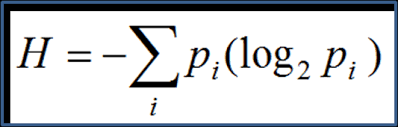

```python
# Importing image into jupyter notebook from code block
from IPython.display import Image
Image(filename='D:/Personal/LEARNING/DATA SCIENCE/PRACTICE/Entropy_Formula.png')
```

```python
from sklearn.tree import DecisionTreeClassifier
```

```python
# input and output
x = df[['proline']]
#x = df.drop('wine_type',axis=1)
y = df['wine_type']
```

```python
clf = DecisionTreeClassifier()
clf
```

```
DecisionTreeClassifier(class_weight=None, criterion='gini', max_depth=None,
            max_features=None, max_leaf_nodes=None,
            min_impurity_decrease=0.0, min_impurity_split=None,
            min_samples_leaf=1, min_samples_split=2,
            min_weight_fraction_leaf=0.0, presort=False, random_state=None,
            splitter='best')
```

```python
clf.fit(x,y)
pred = clf.predict(x)
```

```python
metrics.accuracy_score(y, pred)
```

```
0.8876404494382022
```

```python
# input and output
x = df.drop('wine_type',axis=1)
y = df['wine_type']
```

```python
clf.fit(x,y)
pred = clf.predict(x)
```

```python
metrics.accuracy_score(y, pred)
```

```
1.0
```

> It seems the model is overfitted since we are training and testing on the same data.

## Random Forest

> Random forests which is a forest made up of many decision trees, it's part of a ensemble learning family and ensemble learning means multiple learning algorithms coming together which will yield better predictive performance than the ones constituting the ensemble.

> Usually one or two level deep trees or enough for random forests to perform much better than a single decision tree.

> The input data is subsampled with bootstrapping and the features are also randomly selected, the number of features selected is generally the square root of the number of total features, also bootstrapping means random selection with replacement meaning the same sample the same input the same row basically from the data can be selected multiple times in same data set.

> So the final decision depends on the majority vote, this helps decrease the high variance that results from using a single tree. Single tree has high variance meaning it highly depends on the data input. If there's a slight change in the input data the decision tree might also change quite a bit, so that's why it says high variance.

> By having many trees overcomes this problem, and also this results in a more robust and generalizable algorithm compared to decision trees. The variables that are used by many trees will hint their importance, so since the features are selected randomly, if they appear to be selected in many decision trees, you know as a first or second node, then that means that those variables are important those features are important compared to the others.

```python
from sklearn.ensemble import RandomForestClassifier
```

```python
df.head()
```

|  | alcohol | malic_acid | ash | alcalinity_of_ash | magnesium | total_phenols | flavanoids | nonflavanoid_phenols | proanthocyanins | color_intensity | hue | od280/od315_of_diluted_wines | proline | wine_type |
| --- | --- | --- | --- | --- | --- | --- | --- | --- | --- | --- | --- | --- | --- | --- |
| 0 | 14.23 | 1.71 | 2.43 | 15.6 | 127.0 | 2.80 | 3.06 | 0.28 | 2.29 | 5.64 | 1.04 | 3.92 | 1065.0 | 0 |
| 1 | 13.20 | 1.78 | 2.14 | 11.2 | 100.0 | 2.65 | 2.76 | 0.26 | 1.28 | 4.38 | 1.05 | 3.40 | 1050.0 | 0 |
| 2 | 13.16 | 2.36 | 2.67 | 18.6 | 101.0 | 2.80 | 3.24 | 0.30 | 2.81 | 5.68 | 1.03 | 3.17 | 1185.0 | 0 |
| 3 | 14.37 | 1.95 | 2.50 | 16.8 | 113.0 | 3.85 | 3.49 | 0.24 | 2.18 | 7.80 | 0.86 | 3.45 | 1480.0 | 0 |
| 4 | 13.24 | 2.59 | 2.87 | 21.0 | 118.0 | 2.80 | 2.69 | 0.39 | 1.82 | 4.32 | 1.04 | 2.93 | 735.0 | 0 |

```python
# input and output
x = df[['proline']]
#x = df.drop('wine_type',axis=1)
y = df['wine_type']
```

```python
clf = RandomForestClassifier()
clf
```

```
RandomForestClassifier(bootstrap=True, class_weight=None, criterion='gini',
            max_depth=None, max_features='auto', max_leaf_nodes=None,
            min_impurity_decrease=0.0, min_impurity_split=None,
            min_samples_leaf=1, min_samples_split=2,
            min_weight_fraction_leaf=0.0, n_estimators='warn', n_jobs=None,
            oob_score=False, random_state=None, verbose=0,
            warm_start=False)
```

```python
clf.fit(x,y)
pred = clf.predict(x)
metrics.accuracy_score(y, pred)
```

```
0.8764044943820225
```

```python
# input and output
x = df.drop('wine_type',axis=1)
y = df['wine_type']
```

```python
clf.fit(x,y)
pred = clf.predict(x)
metrics.accuracy_score(y,pred)
```

```
1.0
```

## K-Means Clustering

> K-Means clustering in which no labels are used so it's a unsupervised learning method.

> The basic principle is to cluster the points to the nearest centroid, there are K number of centroids so that means the mean of the cluster.

> The algorithm is very similar to k-nearest neighbors, however that one is supervised and instance-based learning, meaning all points in the training data are very used to classify new points, whereas the k-means only uses the k centroids to cluster the points.

> Observations are clustered into K groups, where each observation is assigned to the group with a nearest mean.

> Need to decide on K, the created clusters can be used as a feature for other algorithms so this is one of the uses of k-means it can be used as a feature or another algorithm.

> Used in market segmentation image segmentation and more.

> Not friendly with a non numerical data, again the reason is as it was in the k-nearest neighbors it's based on this distance, so distance calculation for categorical variables is not very sensible.

> Good when groups are distinct and linearly separable, not good when too much overlapping too much noise or outliers are present in the data.

```python
from sklearn.cluster import KMeans
```

```python
clu = KMeans(n_clusters=3)
clu
```

```
KMeans(algorithm='auto', copy_x=True, init='k-means++', max_iter=300,
    n_clusters=3, n_init=10, n_jobs=None, precompute_distances='auto',
    random_state=None, tol=0.0001, verbose=0)
```

```python
# input
#x = df[['proline']]
x = df.drop('wine_type',axis=1)
```

```python
clu.fit(x)
pred = clu.predict(x)
```

```python
# Probably we use this prediction as an input to the other algorithm
x['pred'] = pred
```